# Hidden Markov Models: Basics for animal movement data

```
## Decoding state sequence... DONE
```

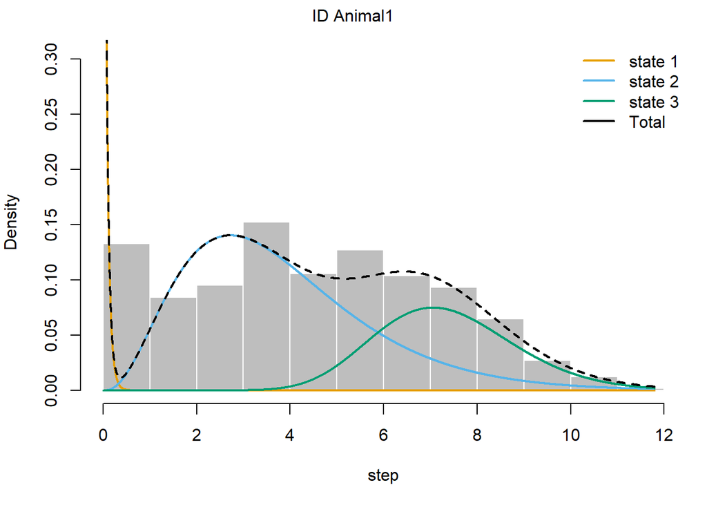

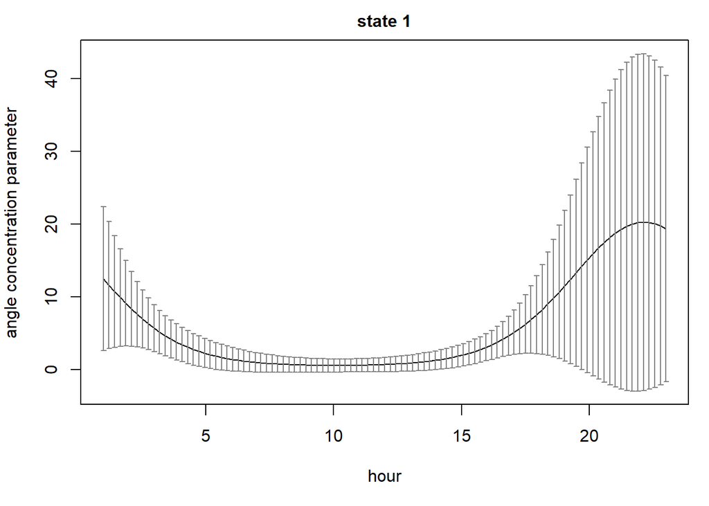

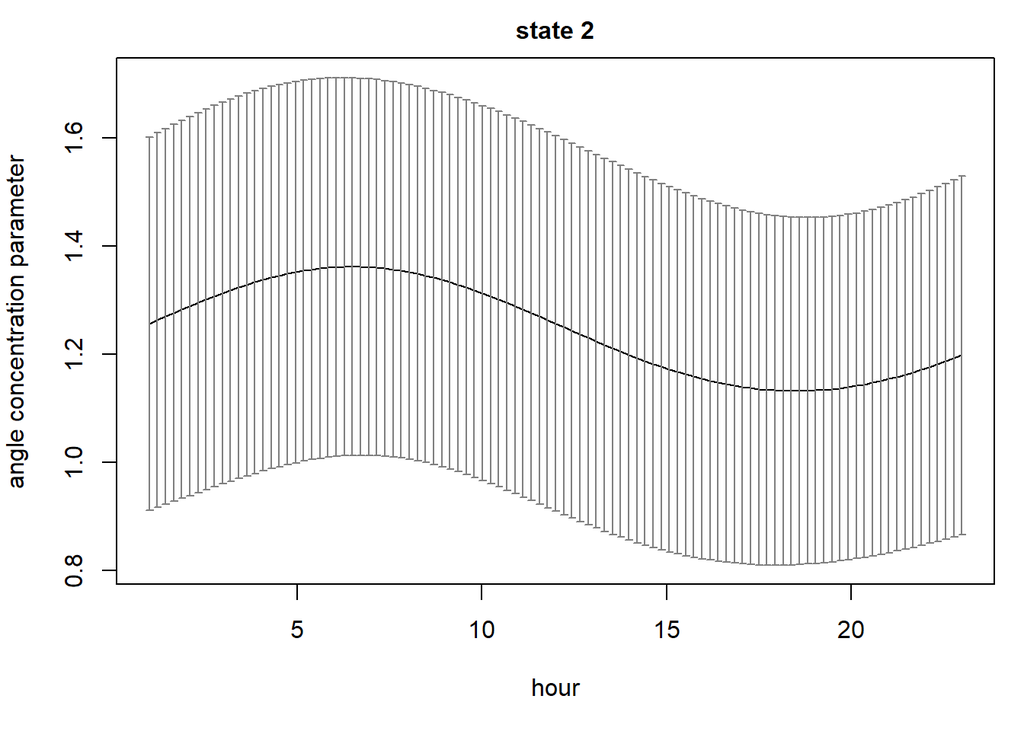

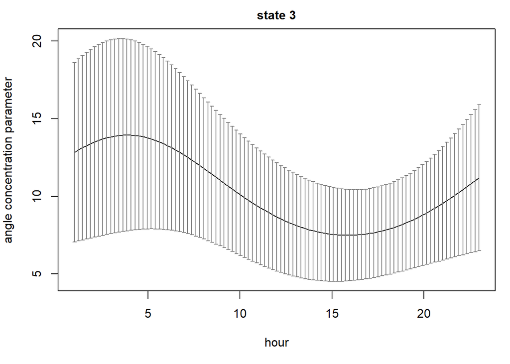

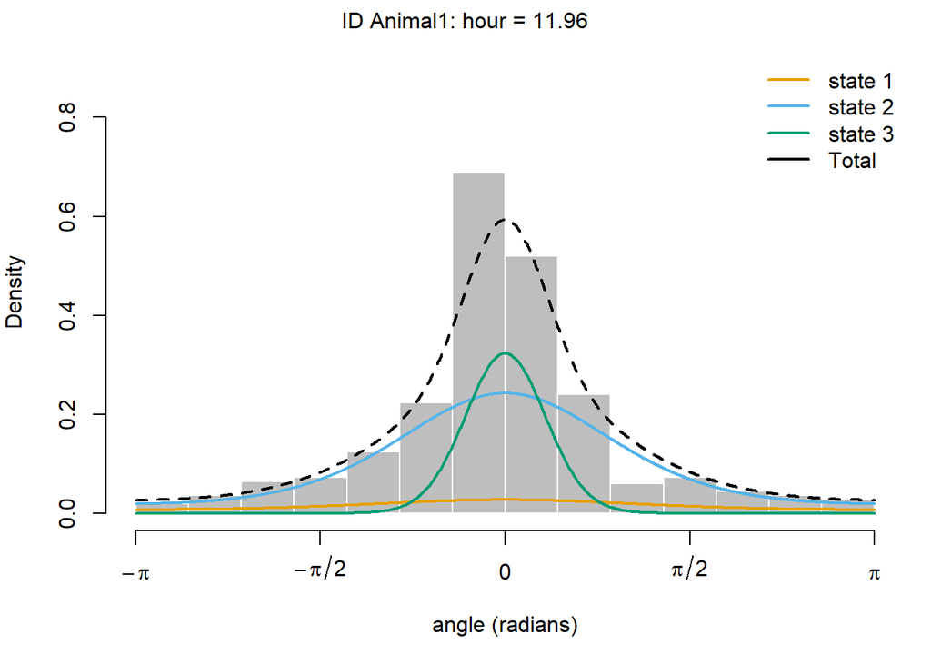

```r
plot(sealHMMdiurnDM, plotCI=TRUE)
```

```r
AIC(sealHMMb, sealHMMdiurn, sealHMMdiurnDM)
```

```
##            Model      AIC
## 1       sealHMMb 3218.748
## 2 sealHMMdiurnDM 3235.313
## 3   sealHMMdiurn 3241.615
```

So here it looks like the seal makes more directed movement in state 1 at night, makes more directed movement in state 2 early in the morning, and makes more directed movement in state 3 early in the morning.

Note that we can combine various covariates. For example, here we are going to combine bathymetry and time of day.

```r
# Get parameter starting values
par0bd <- getPar0(model=sealHMM3s, formula=bathyForm, DM=diurnDM)

# Now we fit the new model with the starting values returned by getPar0
sealHMMbd <- fitHMM(sealPrep, nbState = 3,
                        dist=list(step="gamma", angle="vm"),
                        Par0 = par0bd$Par, beta0=par0bd$beta,
                        formula=bathyForm,
                        DM=diurnDM)
```

```r
# Let's look at the results
sealHMMbd
```

```
## Value of the maximum log-likelihood: -1573.811
##
##
## step parameters:
## ----------------
##         state 1  state 2  state 3
## mean 0.04628764 3.814690 7.375478
## sd   0.05798717 2.027531 1.521130
##
## Regression coeffs for angle parameters:
## ---------------------------------------
##      concentration_1:(Intercept) concentration_1:cosinorCos(hour, period = 24)
## [1,]                    1.202685                                      1.580225
##      concentration_1:cosinorSin(hour, period = 24) concentration_2:(Intercept)
## [1,]                                    -0.8329409                   0.2230671
##      concentration_2:cosinorCos(hour, period = 24)
## [1,]                                  -0.009034684
##      concentration_2:cosinorSin(hour, period = 24) concentration_3:(Intercept)
## [1,]                                     0.0889005                    2.327927
##      concentration_3:cosinorCos(hour, period = 24)
## [1,]                                     0.1680628
##      concentration_3:cosinorSin(hour, period = 24)
## [1,]                                     0.2653592
##
## angle parameters (based on mean covariate values):
## --------------------------------------------------
##                 state 1  state 2  state 3
## concentration 0.6789665 1.262561 8.697043
##
## Regression coeffs for the transition probabilities:
## ---------------------------------------------------
##                  1 -> 2     1 -> 3    2 -> 1      2 -> 3   3 -> 1        3 -> 2
## (Intercept) -2.47760055 -3.5165634 0.5995146 -1.68027222 21.03511 -2.6990810733
## bathy        0.01086906  0.1225144 0.6683035  0.01467618 20.91027  0.0008083147
##
## Transition probability matrix (based on mean covariate values):
## ---------------------------------------------------------------
##              state 1    state 2      state 3
## state 1 9.841482e-01 0.01585182 2.422263e-10
## state 2 1.470203e-44 0.98034213 1.965787e-02
## state 3 0.000000e+00 0.05615452 9.438455e-01
##
## Initial distribution:
## ---------------------
##      state 1      state 2      state 3
## 9.999785e-01 9.367060e-06 1.217008e-05
```

```
## Decoding state sequence... DONE
```

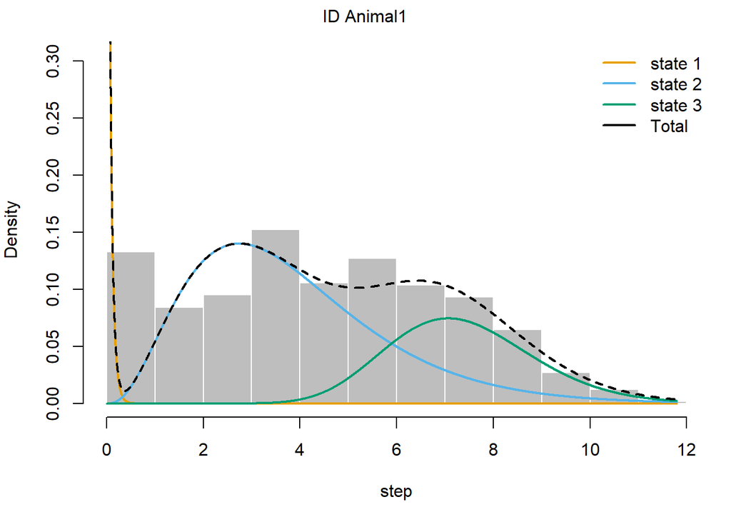

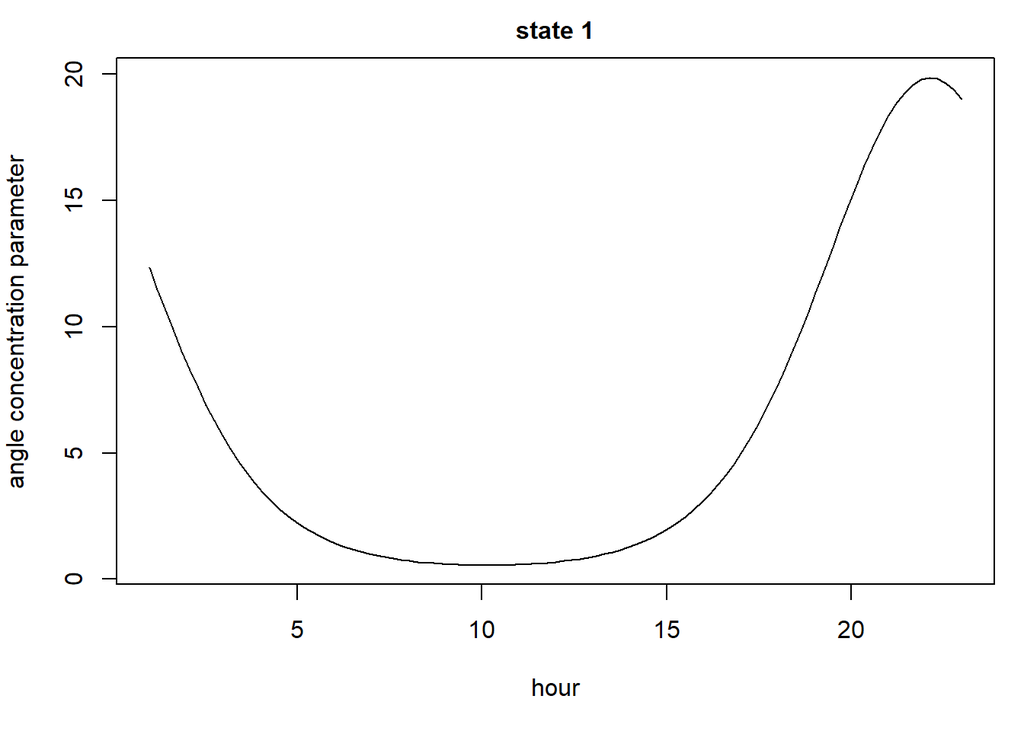

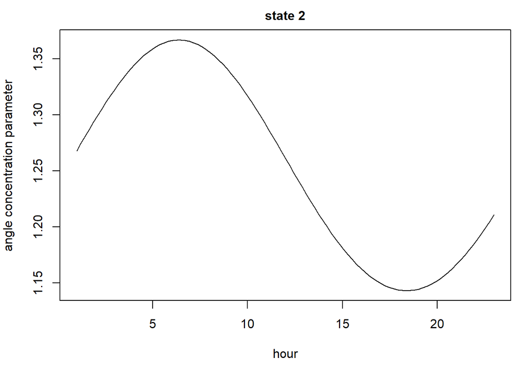

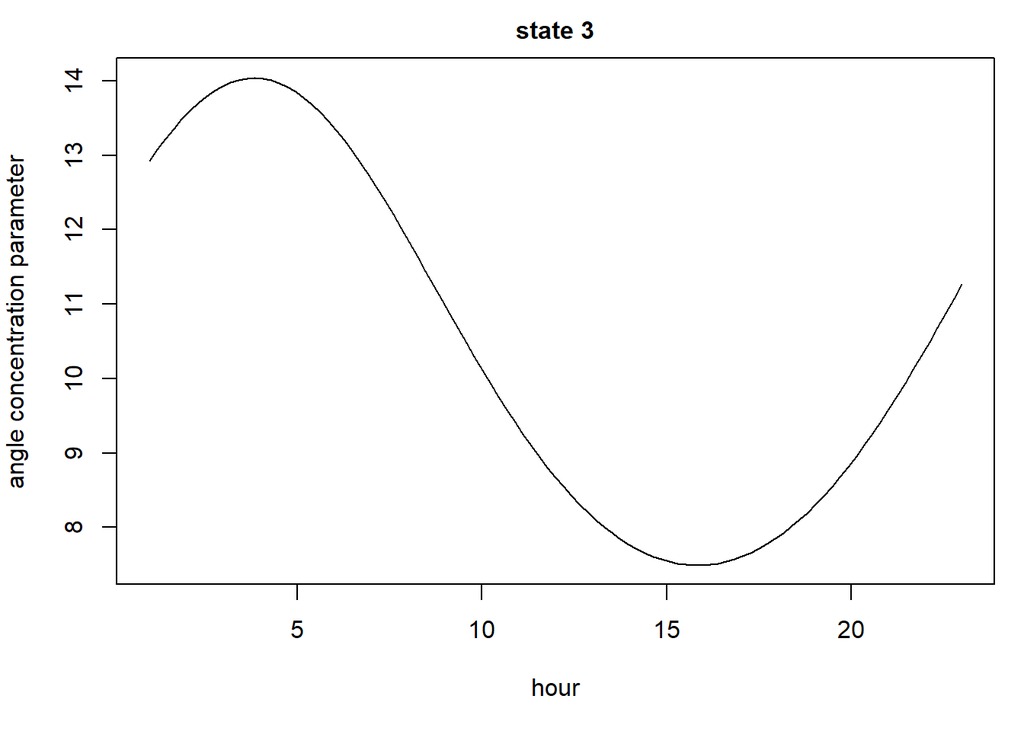

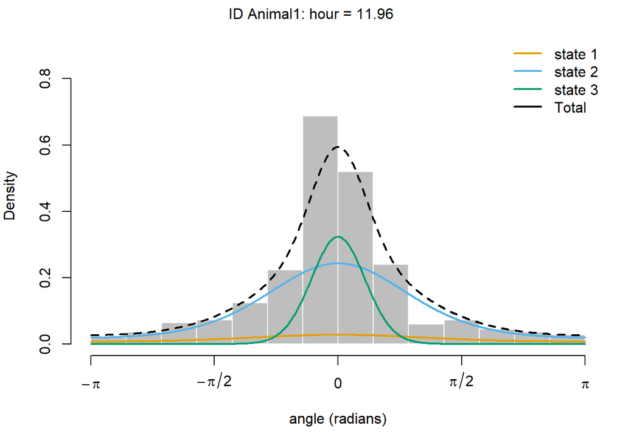

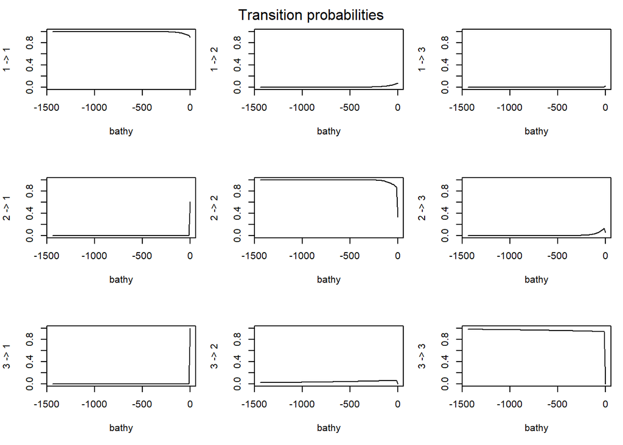

```r
plot(sealHMMbd)
```

```r
AIC(sealHMMb, sealHMMdiurn, sealHMMdiurnDM, sealHMMbd)
```

```
##            Model      AIC
## 1      sealHMMbd 3205.621
## 2       sealHMMb 3218.748
## 3 sealHMMdiurnDM 3235.313
## 4   sealHMMdiurn 3241.615
```

```
## Computing pseudo-residuals...
```

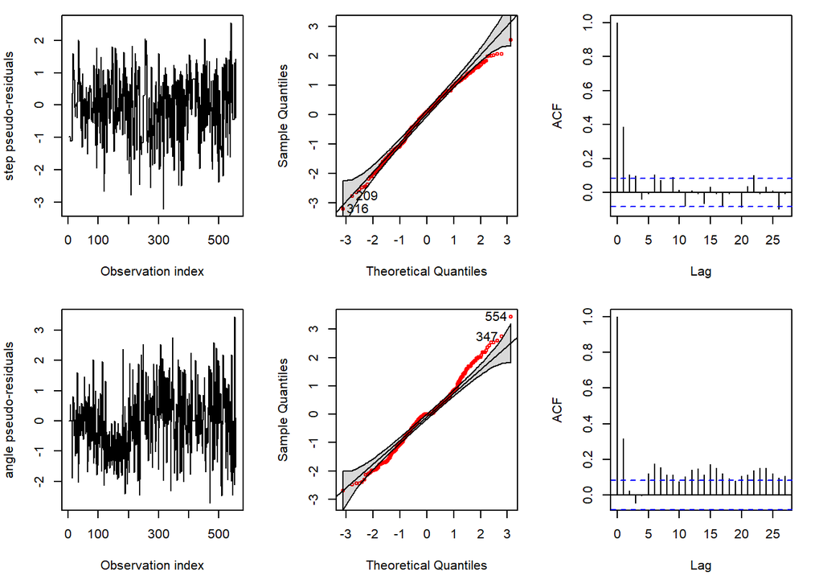

```r
plotPR(sealHMMbd)
```

While this combined model is better, given the complexity, I think I would stick to the bathymetry model for the moment and look into better ways to try to explain the data, especially since incorporating the time of day doesn’t fix the angle pseudo-residual problem.

This is where we stop the main tutorial. There are two other sections below. One that describes some of the mathematical details and one with activities that you can do on your own to further explore HMMs.

# 5 For the statistically/mathematically inclined

One of the most exciting aspect of the `momentuHMM` package is that you can incorporate the potential effects of environmental covariates on the probability of switching behavioural states. To understand how the covariates can affect the behaviour, it’s useful to spend time understanding the transition probabilities. This section is a bit more technical, but I think is needed to fully understand what the estimated covariate relationships mean.

If you have a model that has two behavioural states (state 1 and 2) and no covariates, you would have a transition probability matrix like this:

$$\begin{equation}
\mathbf{\Gamma} =
\begin{pmatrix}
\gamma_{11} & \gamma_{12}\\
\gamma_{21} & \gamma_{22} \tag{5.1}
\end{pmatrix}
\end{equation}$$
,

where $\gamma_{ij}$ represent the probability of switching from i to j. For example, $\gamma_{11}$ represents the probability of staying in state 1 if you are already in state 1. Similarly, $\gamma_{12}$ represents the probability of switching to state 2 if you are in state 1. By definition the row entries need to sum to 1. Which simply means that if you are in state 1 at time $t-1$ you will end up in a state at time $t$ (i.e., you don’t go in behavioural limbo).

Let’s look again at the transition probability matrix that was estimated in our seal example.

```r
sealHMM2s
```

```
## Value of the maximum log-likelihood: -1810.643
##
##
## step parameters:
## ----------------
##         state 1  state 2
## mean 0.05014674 4.902540
## sd   0.06428475 2.689235
##
## angle parameters:
## -----------------
##                state 1  state 2
## mean          0.000000 0.000000
## concentration 2.789105 1.771596
##
## Regression coeffs for the transition probabilities:
## ---------------------------------------------------
##                1 -> 2    2 -> 1
## (Intercept) -2.346327 -4.840843
##
## Transition probability matrix:
## ------------------------------
##             state 1    state 2
## state 1 0.912641818 0.08735818
## state 2 0.007838462 0.99216154
##
## Initial distribution:
## ---------------------
##      state 1      state 2
## 9.999995e-01 5.269109e-07
```

We can see that the probability of switching in state 2 if you are in state 1 is 0.09 and so the probability of staying in state 1 is 0.91=0.91. The same logic applies to the probability of staying or switching from state 2. This means that for a model with $N$ behavioural states, we only need to estimate $N (N-1)$ transition probabilities (so 2 for the example here), because for each state at time $t-1$ we will be able to calculate one of the transition probabilities based on the difference with the sum of the transition probabilities estimated (so here we can deduce $\gamma_{11}$ based on $\gamma_{12}$).

To incorporate the covariates we are saying that the transition probabilities are changing through time as a function of the covariate values at that time step. Specifically,

$$\begin{equation}
\label{eq:linkFx}
\gamma^{(t)}_{ij} = \frac{\exp(\eta_{ijt})}{\sum^N_{k=1}\exp(\eta_{ikt})}, \tag{5.2}
\end{equation}$$

where

$$\begin{equation}
\label{eq:covRel}
\eta_{ijt} =\begin{cases}\beta_{0ij} + \sum^p_{l=1} \beta_{lij} w_{lt} & \text{if} \ i \neq j,\\0, & \text{otherwise},\end{cases}\tag{5.3}
\end{equation}$$

where $w_{lt}$ is the $l$-th covariate at time $t$ and $p$ is the number of covariates considered. Equation $\ref{eq:linkFx}$ is only a link function to insure that the transitions probabilities are between 0 and 1 and that the row sum to 1. The important relationship between the covariates and the transition probabilities are in equation $\ref{eq:covRel}$, where the $\beta_{0ij}$ is the base transition probability for the switch from state $i$ to state $j$ that is not affected by the covariates. The $\beta_{lij}$ are the coefficient relating the transition probability to the $l$-th covariate. Note that $\eta_{ii}$ (the probability of staying in state $i$, the diagonal values in the transition probability matrix) are fixed to 0 because we only want to $N (N-1)$ transition probabilities to be estimated and the row sums to one.

So in a model with no covariates, only the $\beta_{0ij}$ for $i \neq j$ (switching probabilities from state $i$ to another state $j$) are estimated. If you look in the code box above you’ll see that we only have for 1 $->$ 2 and 2 $->$ 1, and that the transition probabilities for corresponding states are $\gamma_{ij} = \frac{\exp(\eta_{ij})}{\sum^N_{k=1}\exp(\eta_{ik})}$.

For example, for the transition probability from state 1 to state 2.

```r
# gamma_{12}
sealHMM2s$mle$gamma[1,2]
```

```
## [1] 0.08735818
```

```r
# gamma_{12} calculated based on the equations above
exp(sealHMM2s$mle$beta[1])/(exp(0)+exp(sealHMM2s$mle$beta[1]))
```

```
## [1] 0.08735818
```

So the way we interpret the $\beta$ values, is that if they are positive, it means that they increase the transition probability. Since the total value of $\eta$ is what affects the transition probability, the magnitude and sign of the intercept ($\beta_0$) will affect when the transition probability goes from above or below 0.5.

This is a great way to incorporate covariates, but it means that it add $N(N-1)$ parameters to your model, where $N$ is the number of states. So if you have many behavioural states, it will results in a very complex model.

## 5.1 cosinor

The function `cosinor` internally creates the covariates cos$(2 \pi \; \text{value}/\text{period})$ and sin$(2 \pi \; \text{value}/\text{period})$. So for example cos$(2 \pi \; \text{hour}/24)$.

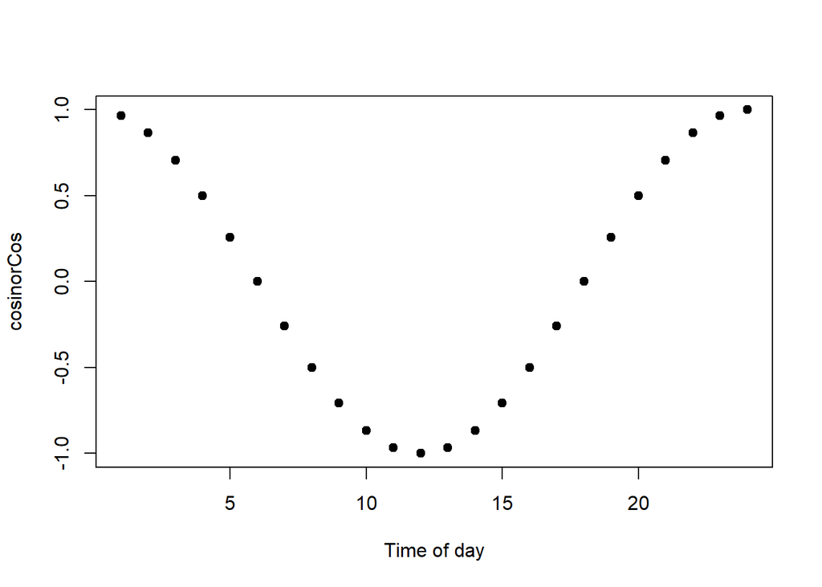

```r
plot(cos(2*pi*(1:24)/24), pch=19, ylab="cosinorCos", xlab="Time of day")
```

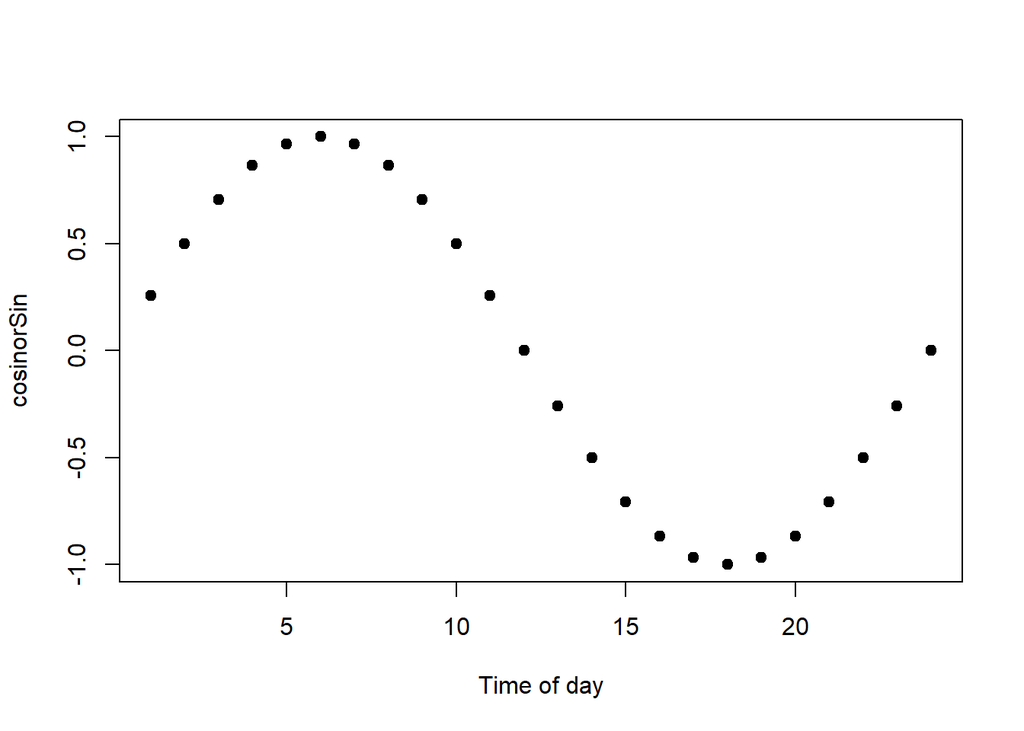

```r
plot(sin(2*pi*(1:24)/24), pch=19, ylab="cosinorSin", xlab="Time of day")
```